# Normalization performance report

- study: Methylation: ROSMAP
- author: Chloe Yap
- date: 03 August, 2021

## Parameters used to test normalization

```
## $variables
## [1] "plate"       "Slide"       "sentrix_row" "sentrix_col" "Sex"
##
## $control.pcs
##  [1]  1  2  3  4  5  6  7  8  9 10
##
## $batch.pcs
##  [1]  1  2  3  4  5  6  7  8  9 10
##
## $batch.threshold
## [1] 0.01
##
## $colours
## NULL
```

## Control probe scree plots

The variance captured by each principal component.

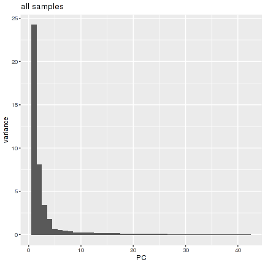

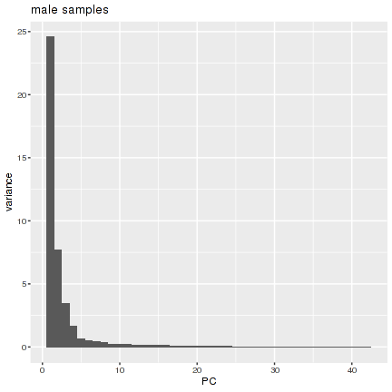

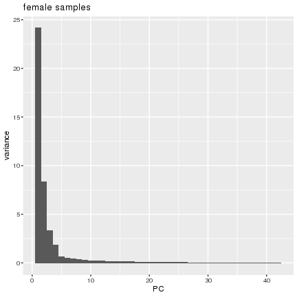

## Principal components of the control probes

The following plots show the first 3 principal components of the control matrix colored by batch variables. Batch variables with more than 10 levels are omitted.

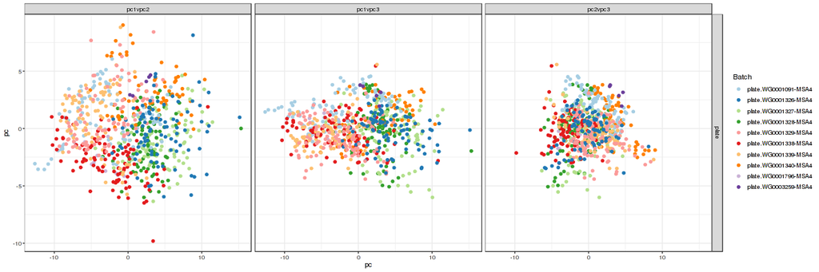

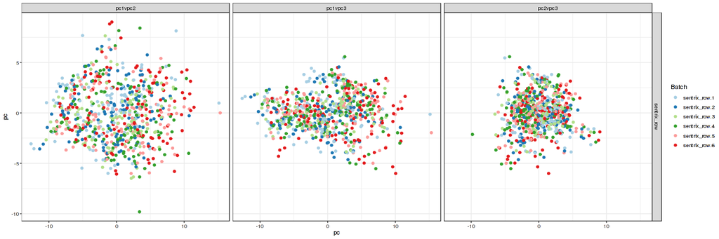

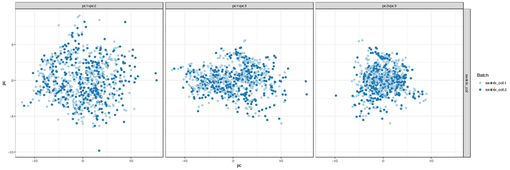

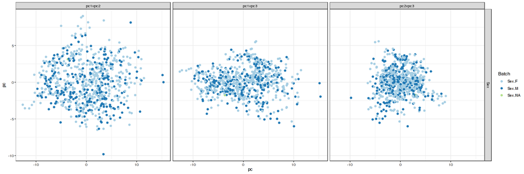

## Control probe associations with measured batch variables

Principal components of the control probes were regressed against batch variables. Shown are the \(-log_{10}\) p-values for these regressions. The horizontal dotted line denotes \(p = 0.05\) in log-scale.

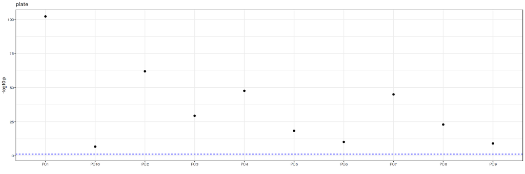

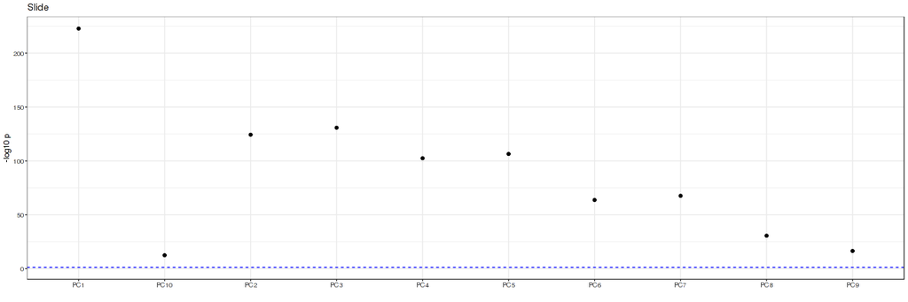

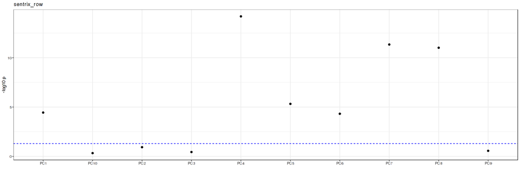

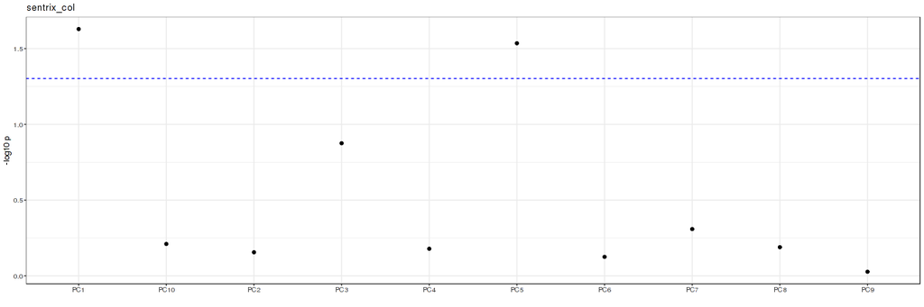

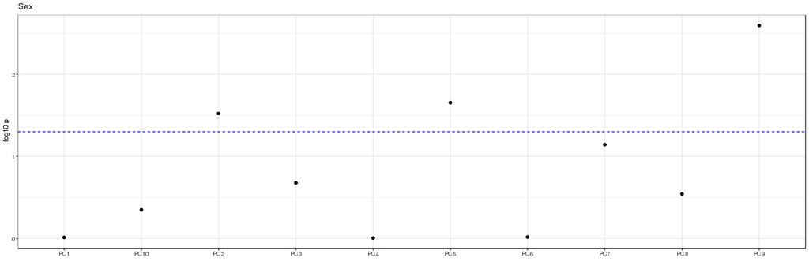

The following plots show regression coefficients when each principal component is regressed against each batch variable level along with 95% confidence intervals. Cases significantly different from zero are coloured red (p < 0.01, t-test).

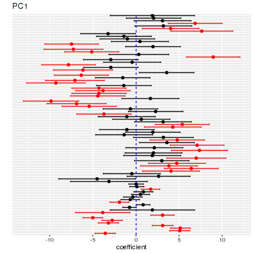

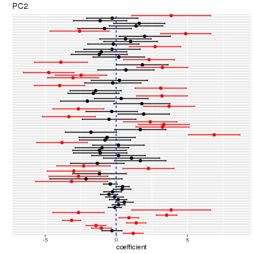

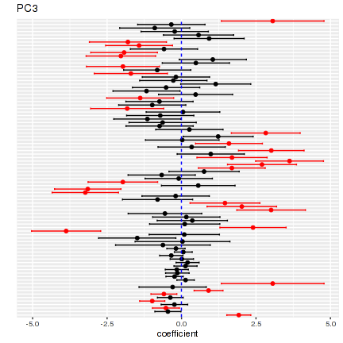

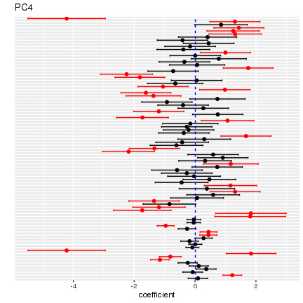

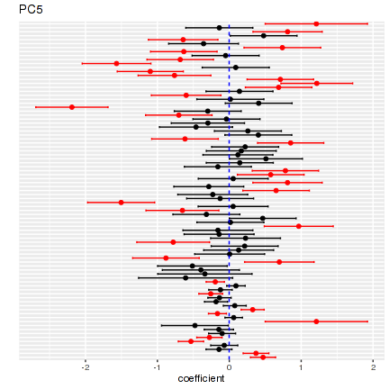

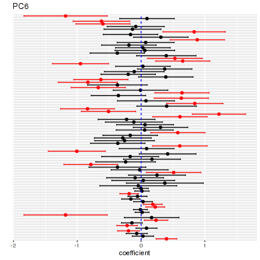

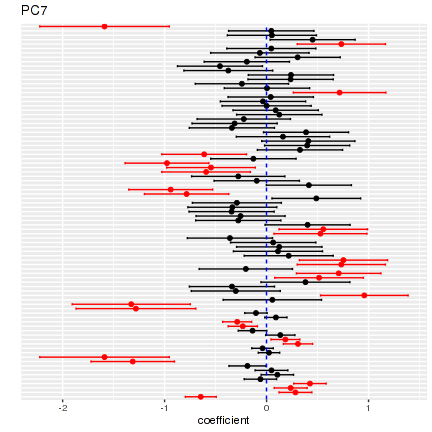

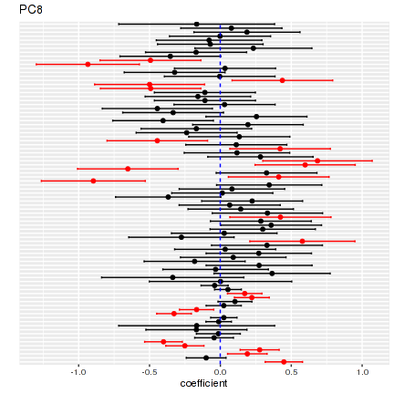

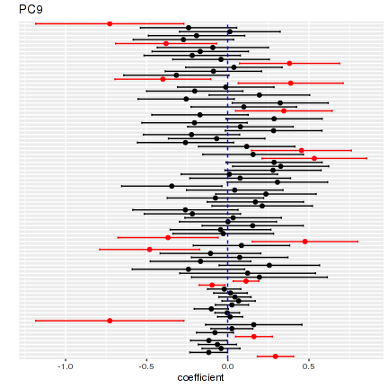

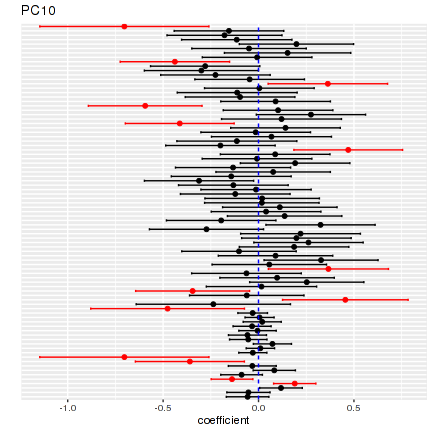

| batch.variable | batch.value | principal.component | test | p.value | estimate | lower | upper |
| --- | --- | --- | --- | --- | --- | --- | --- |
| plate |  | PC1 | F-test | 7.50e-103 | 81.0972 |  |  |
| plate | WG0001796-MSA4 | PC1 | t-test | 6.43e-03 | -3.8507 | -7.0060 | -0.6955 |
| plate | WG0001328-MSA4 | PC1 | t-test | 1.91e-08 | 3.0976 | 1.8825 | 4.3127 |
| plate | WG0001327-MSA4 | PC1 | t-test | 5.42e-22 | 5.1451 | 3.9939 | 6.2963 |
| plate | WG0001340-MSA4 | PC1 | t-test | 4.50e-07 | 3.0823 | 1.7313 | 4.4332 |
| plate | WG0001091-MSA4 | PC1 | t-test | 3.72e-11 | -3.5569 | -4.7369 | -2.3768 |
| plate | WG0001338-MSA4 | PC1 | t-test | 2.71e-07 | -2.7562 | -3.9395 | -1.5729 |
| plate | WG0001339-MSA4 | PC1 | t-test | 3.32e-21 | -5.0032 | -6.1463 | -3.8602 |
| plate | WG0001326-MSA4 | PC1 | t-test | 6.11e-21 | 5.0736 | 3.9058 | 6.2414 |
| plate | WG0001329-MSA4 | PC1 | t-test | 2.33e-09 | -3.1910 | -4.3667 | -2.0153 |
| Slide |  | PC1 | F-test | 1.52e-223 | 55.9315 |  |  |
| Slide | 5815381006 | PC1 | t-test | 5.91e-03 | 4.0597 | 0.7667 | 7.3528 |
| Slide | 5815381007 | PC1 | t-test | 5.03e-06 | 6.4183 | 3.2925 | 9.5442 |
| Slide | 5815381008 | PC1 | t-test | 9.45e-03 | 3.8283 | 0.5333 | 7.1234 |
| Slide | 5815381009 | PC1 | t-test | 1.30e-03 | 4.7370 | 1.4503 | 8.0237 |
| Slide | 5815381014 | PC1 | t-test | 5.45e-06 | 6.9956 | 3.5755 | 10.4156 |
| Slide | 5815381018 | PC1 | t-test | 5.12e-07 | 7.3604 | 4.1077 | 10.6130 |
| Slide | 5815381023 | PC1 | t-test | 4.33e-07 | 7.0963 | 3.9807 | 10.2118 |
| Slide | 5815381026 | PC1 | t-test | 6.80e-04 | 4.7939 | 1.6477 | 7.9401 |
| Slide | 5821203010 | PC1 | t-test | 3.79e-03 | 4.2687 | 0.9775 | 7.5599 |
| Slide | 5821203011 | PC1 | t-test | 1.38e-04 | 5.3724 | 2.2328 | 8.5121 |
| Slide | 5822020003 | PC1 | t-test | 8.68e-03 | -3.7091 | -6.8656 | -0.5526 |
| Slide | 5822020006 | PC1 | t-test | 1.18e-04 | -5.4255 | -8.5645 | -2.2865 |
| Slide | 5822020007 | PC1 | t-test | 7.66e-06 | -6.8861 | -10.3077 | -3.4645 |
| Slide | 5822020008 | PC1 | t-test | 1.31e-11 | -9.8489 | -13.0550 | -6.6427 |
| Slide | 5822020010 | PC1 | t-test | 1.75e-03 | -4.4187 | -7.5687 | -1.2686 |
| Slide | 5822038001 | PC1 | t-test | 2.40e-03 | -4.2863 | -7.4376 | -1.1350 |
| Slide | 5822038002 | PC1 | t-test | 6.82e-03 | -3.8234 | -6.9789 | -0.6679 |
| Slide | 5822038003 | PC1 | t-test | 2.38e-03 | -4.2911 | -7.4424 | -1.1398 |
| Slide | 5822038005 | PC1 | t-test | 1.28e-09 | -9.2861 | -12.6677 | -5.9045 |

[output cut: 286 more lines]

## Principal components of the normalized betas

The following plots show the first 3 principal components of the most variable probes colored by batch variables. Batch variables with more than 10 levels are omitted.

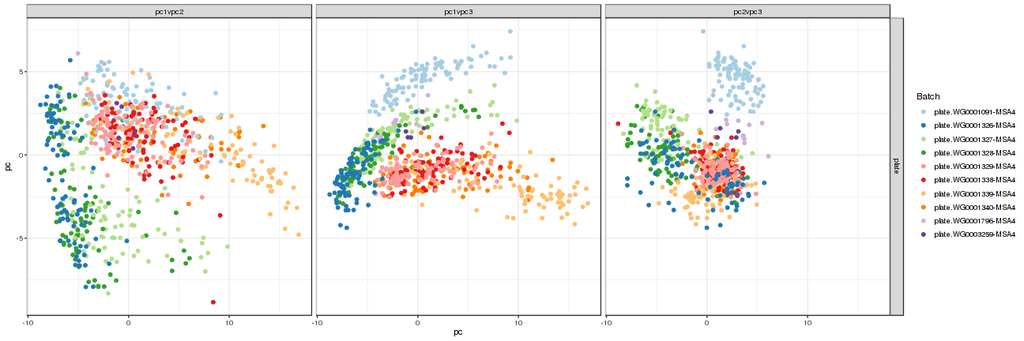

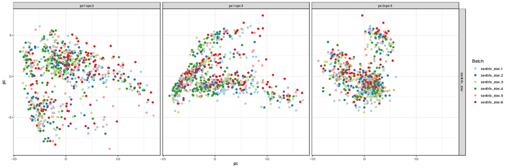

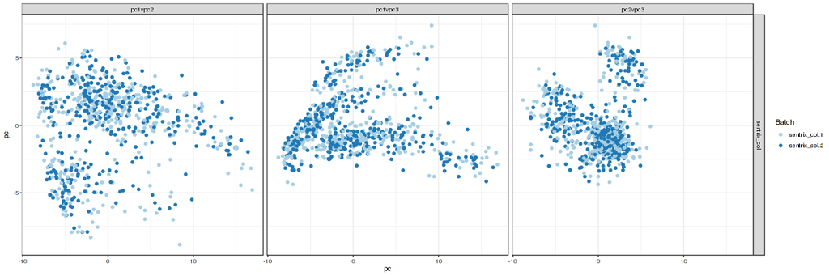

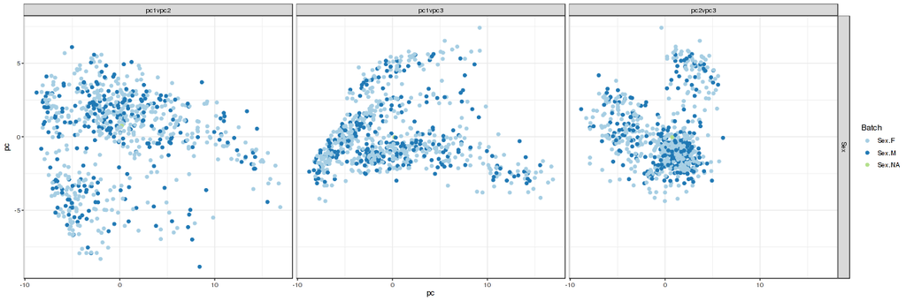